# aula_5_automacao

#### Criando Funções Reutilizáveis

Escrever funções modulares e bem documentadas é essencial para a criação de pacotes eficientes. Aqui estão algumas práticas recomendadas:

- **Funções Modulares:** Escreva funções que realizam uma única tarefa específica. Isso facilita a manutenção e a reutilização do código.
- **Boas Práticas de Nomeação:** Use nomes de funções claros e descritivos. Funções que realizam operações semelhantes devem ter nomes consistentes.
- **Documentação Completa:** Sempre documente seus parâmetros, valores de retorno e qualquer comportamento importante da função.

Exemplo de uma função modular e bem documentada:

```r
#' Raspar Tabela de uma Página Web
#'
#' Esta função raspas tabelas de uma página web específica.
#'
#' @param url Uma string com a URL da página a ser raspada.
#' @return Um dataframe contendo os dados da tabela raspada.
#' @export
raspar_tabela <- function(url) {
  # Ler o conteúdo da página web
  pagina <- read_html(url)
  # Extrair a tabela
  tabela <- pagina %>% html_nodes("table") %>% html_table()
  # Retornar o primeiro dataframe (caso haja mais de uma tabela)
  return(tabela[[1]])
}
```

### 4. Automação de Rotinas de Web Scraping

Automatizar rotinas de web scraping é uma prática poderosa que permite coletar dados de maneira contínua e eficiente. Nesta seção, veremos como criar scripts automatizados de web scraping e como agendar a execução dessas tarefas.

#### Scripts Automatizados

Para automatizar o web scraping, você precisa criar scripts que possam ser executados de forma autônoma, sem intervenção manual. Abaixo está um exemplo de script R que realiza web scraping:

```r
raspar_dados <- function(url) {
  pagina <- rvest::read_html(url)
  tabela <- pagina |> rvest::html_nodes("table") |> rvest::html_table()
  return(tabela[[1]])
}

# URL do site a ser raspado
url <- "https://exemplo.com/tabela"

# Raspando os dados
dados <- raspar_dados(url)

# Salvando os dados em um arquivo CSV
write.csv(dados, "dados_raspados.csv", row.names = FALSE)
```

#### Agendamento de Tarefas

Para garantir que o script seja executado regularmente, podemos agendar sua execução utilizando cron jobs diretamente no R.

##### Cron Jobs no R

No Linux/Mac, cron jobs são tarefas agendadas que podem ser configuradas para executar scripts em intervalos regulares. Vamos usar o pacote `cronR` para facilitar essa tarefa diretamente no R.

##### Instalando e Configurando o `cronR`

Primeiro, certifique-se de que o pacote `cronR` está instalado:

```r
install.packages("cronR")
```

##### Criando um Job com `cronR`

1. **Criar um Comando Cron:** Definimos o comando cron que executará nosso script. O script deve estar salvo em um arquivo, por exemplo, `meu_script.R`.

   ```r
   script_path <- "/caminho/para/meu_script.R"
   cron_cmd <- cron_rscript(script_path)
   ```

2. **Adicionar o Job ao Crontab:** Adicione uma tarefa ao crontab que execute o script todos os dias às 2:00 AM.

   ```r
   cron_add(cron_cmd, frequency = "daily", at = "2AM", id = "meu_webscraper", description = "Tarefa de Web Scraping diária")
   ```

3. **Listar Tarefas Agendadas:** Para verificar as tarefas agendadas:

   ```r
   cron_ls()
   ```

4. **Remover um Job:** Para remover uma tarefa agendada:

   ```r
   cron_rm("meu_webscraper")
   ```

Automatizar rotinas de web scraping não só economiza tempo, mas também garante a coleta consistente e atualizada de dados. Usar scripts bem estruturados e agendá-los corretamente são passos fundamentais para uma automação eficaz. O uso de pacotes como `cronR` facilita ainda mais o processo de agendamento diretamente no R, proporcionando uma solução integrada e eficiente.

### 5. Publicação e Distribuição de Pacotes

Publicar e distribuir pacotes R permite que você compartilhe suas funções e dados com a comunidade, facilitando a colaboração e a reutilização do código. A seguir, veremos como compartilhar seu pacote no GitHub.

#### Preparação do pacote

- Certifique-se de que seu pacote está em conformidade com as diretrizes do CRAN. A documentação oficial do CRAN contém todos os requisitos necessários.
- Adicione todos os pacotes utilizados nas funções via `use_package`

  ```r
  usethis::use_package("dplyr")
  ```

- Verifique se todos os testes estão passando e se não há problemas de compilação

  ```r
  devtools::check()
  ```

#### Compartilhamento no GitHub

GitHub é uma plataforma popular para hospedagem e colaboração de código. Publicar seu pacote no GitHub é um excelente primeiro passo para distribuí-lo.

**Criar um Repositório no GitHub:**

- Acesse [GitHub](https://github.com) e crie uma conta se ainda não tiver uma.
- Clique em [“New”](https://github.com/new) para criar um novo repositório.

[figure not shown]

- Dê um nome ao seu repositório, adicione uma descrição e escolha se ele será público ou privado.

[figure not shown]

- Clique em “Create repository”.
- Adicionando arquivos
  - Por padrão fazemos os uploads de arquivos via bash, todavia iremos apresentar nesse curso como fazer esse procedimento via webpage do github, pois acreditamos que esse método é menos sucetível a erros para novos usuários de R que não tem interesse em versionamento
  - Entre no link do seu pacote e clique em uploading an existing file

[figure not shown]

  - Clique em choose files e selecione o diretório. Em seguida clique em commit changes

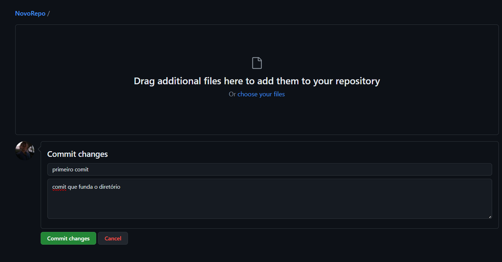